# Venlafaxine 18S - Creating phyloseq objects

Milena Esser

29/04/2025

1. This script creates a phyloseq object from three input files:
- feature_table.tsv
- taxonomy_table.tsv
- metadata.tsv
2. After *creating the phyloseq object*, there is a filtering step to remove contaminated samples, controls, as well as Chloroplasts and Mitochondria.
3. The script includes multiple options to *normalize for varying sequencing depth* (e.g., rarefaction, proportional normalization, CSS) for ecological metrics analysis (e.g., alpha/beta diversity0
4. Lastly, the resulting *phyloseq objects are saved for use in downstream analyses* such as diversity assessment and differential abundance. *(**IMPORTANT**: This includes normalized ps files, as well as the unnormalized ps, as some downstream analysis have their own normalization/transformation methods, e.g., DeSeq2 for differential abundance analysis using variance stabilizing transformation (VST), which normalizes for varying sequencing depth and dispersion*)

# 1 **Create and Filter Phyloseq object**

```
## ASVs removed (non-Eukaryota): 1
```

```
## ASVs removed (Chloroplasts/Mitochondria): 0
```

```
## Final PS object after filtering:
```

```
## phyloseq-class experiment-level object
## otu_table()   OTU Table:         [ 371 taxa and 42 samples ]
## sample_data() Sample Data:       [ 42 samples by 16 sample variables ]
## tax_table()   Taxonomy Table:    [ 371 taxa by 7 taxonomic ranks ]
```

```
## Original number of samples: 42
```

```
## Number of samples remaining after filtering: 42
```

# 2 **Investigating Sequencing Depth**

## 2.1 Rarefaction curve

```
##
## Generating rarefaction curve for sample_type: water
## Min depth: 41 Max depth: 9113 Total reads: 54476
```

```
##
## Generating rarefaction curve for sample_type: biofilm
## Min depth: 1357 Max depth: 11811 Total reads: 88869
```

```
##
## Generating rarefaction curve for sample_type: sediment
## Min depth: 2616 Max depth: 24055 Total reads: 78583
```

## 2.2 Goods coverage estimate

= 1-(F1/N)

F1= number of singletons (reads that only occur once)

N=number of reads per sample

**Rule of thumb:** Values >95% are generally considered good coverage

If your samples show lower coverage, especially inconsistently across groups, this can bias diversity estimates.

```
##
## Calculating Good's Coverage for sample_type: water
## Good's Coverage Summary for water :
##    Min. 1st Qu.  Median    Mean 3rd Qu.    Max.
##  0.9420  0.9767  0.9921  0.9839  0.9972  0.9991
```

```
##
## Calculating Good's Coverage for sample_type: biofilm
## Good's Coverage Summary for biofilm :
##    Min. 1st Qu.  Median    Mean 3rd Qu.    Max.
##  0.9917  0.9956  0.9976  0.9967  0.9984  0.9986
```

```
##
## Calculating Good's Coverage for sample_type: sediment
## Good's Coverage Summary for sediment :
##    Min. 1st Qu.  Median    Mean 3rd Qu.    Max.
##  0.9924  0.9969  0.9975  0.9971  0.9982  0.9995
```

# 3 **Normalization**

Normalization is currently a much-discussed issue of microbiome studies. Differences in read depth between samples often need to be corrected before analysis. Several normalization methods have been proposed, and no single method is perfect. It may be that the most appropriate method depends on the analysis.

## 3.1 Water

### 3.1.1 Rarefaction

Rarefaction can be used to subset data such that the library depth is the same for each sample. Because sampling of the data is random, rarefaction can account for an effect of total read count on taxa richness. The sequencing depth differs considerably between taxonomic groups (spiders have very low read counts), therefore rarefaction may not be ideal for normalization here.

This code helps finding a rarefaction level with a minimum of 3 replicates left per enclosure and sample type

```
## Number of samples in ps_water: 17
```

```
## Number of taxa in ps_water: 196
```

```
## Given the low # of reps, lowest sequencing depth is selected for rarefaction of water samples: 41 :
```

```
## The selected rarefaction level for water samples is: 41  reads
```

```
## rarefied PS object for water (ps_water_rare):
```

```
## phyloseq-class experiment-level object
## otu_table()   OTU Table:         [ 83 taxa and 17 samples ]
## sample_data() Sample Data:       [ 17 samples by 16 sample variables ]
## tax_table()   Taxonomy Table:    [ 83 taxa by 7 taxonomic ranks ]
```

```
## Number of samples left per treatment after rarefaction:
```

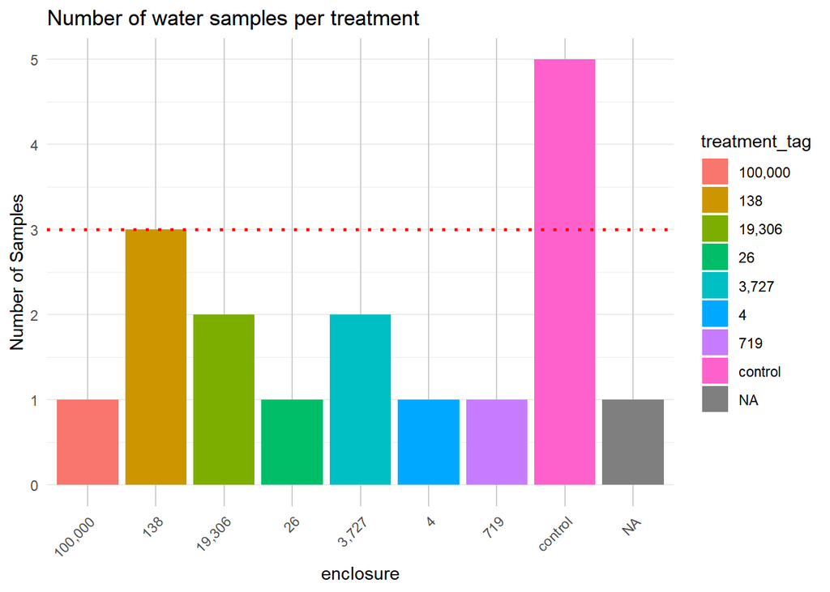

### 3.1.2 Proportion normalization

Proportion normalization involves dividing each OTU count by the total sum for each sample. The resulting count data will add up to 1 (100%) for each sample.

```
## OTU Table:          [5 taxa and 5 samples]
##                      taxa are rows
##         Ven11 Ven13        Ven14      Ven15        Ven17
## Zotu226     0     0 0.0000000000 0.01149425 0.0000000000
## Zotu165     0     0 0.0000000000 0.00000000 0.0000000000
## Zotu46      0     0 0.0000000000 0.00000000 0.0000000000
## Zotu107     0     0 0.0001179523 0.00000000 0.0003710575
## Zotu96      0     0 0.0000000000 0.01149425 0.0000000000
```

```
## Ven11 Ven13 Ven14 Ven15 Ven17 Ven19
##     1     1     1     1     1     1
```

### 3.1.3 Cumulative Sum Scaling (CSS)

The *metagenomeSeq* Cumulative Sum Scaling (CSS) normalization is another option developed for microbiome data. For more information, read [Paulson et al. 2013](http://www.nature.com/articles/nmeth.2658).

```
## OTU Table:          [5 taxa and 5 samples]
##                      taxa are columns
##        Zotu226 Zotu165 Zotu46  Zotu107   Zotu96
## Ven11  0.00000       0      0  0.00000  0.00000
## Ven13  0.00000       0      0  0.00000  0.00000
## Ven14  0.00000       0      0 16.66667  0.00000
## Ven15 68.96552       0      0  0.00000 68.96552
## Ven17  0.00000       0      0 19.60784  0.00000
```

### 3.1.4 **Save phyloseq object for easy reloading**

**Saved phyloseq objects:**

- *ps_water_final* (Unrarefied, filtered): `Venla_water_phyloseq_filt_unnorm.RData`
- *ps_water_rare* (Rarefied to even sequencing depth): `Venla_water_phyloseq_filt_rar.RData`
- *ps_water_prop* (Proportion-normalized to relative abundance): `Venla_water_phyloseq_filt_propnorm.RData`
- *ps_water_css* (CSS-normalized for compositionality and sequencing depth): `Venla_water_phyloseq_filt_css.RData`

## 3.2 Sediment

### 3.2.1 Rarefaction

```
## Number of samples in ps_sediment: 10
```

```
## Number of taxa in ps_sediment: 257
```

```
## Given the low # of reps, lowest sequencing depth is selected for rarefaction of sediment samples: 2616 :
```

```
## The selected rarefaction level for sediment samples is: 2616  reads
```

```
## rarefied PS object for sediment (ps_sediment_rare):
```

```
## phyloseq-class experiment-level object
## otu_table()   OTU Table:         [ 237 taxa and 10 samples ]
## sample_data() Sample Data:       [ 10 samples by 16 sample variables ]
## tax_table()   Taxonomy Table:    [ 237 taxa by 7 taxonomic ranks ]
```

```
## Number of samples left per treatment after rarefaction:
```

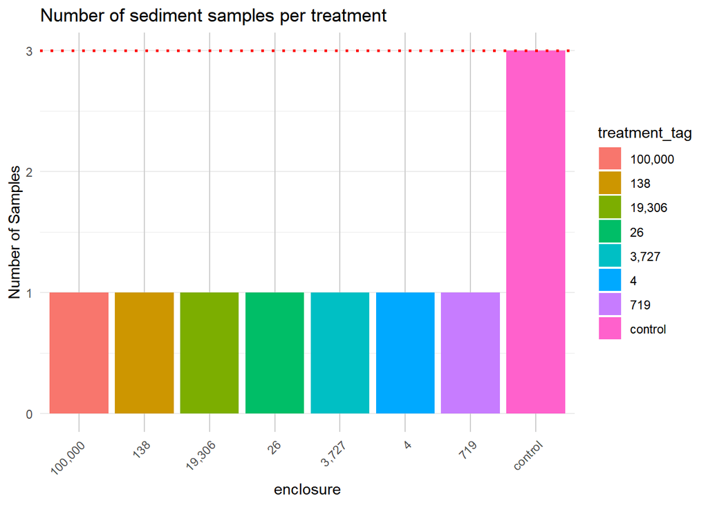

### 3.2.2 Proportion normalization

```
## OTU Table:          [5 taxa and 5 samples]
##                      taxa are rows
##         10S          1S          2S          3S         4S
## Zotu267   0 0.000000000 0.000000000 0.000000000 0.00000000
## Zotu325   0 0.005097087 0.000000000 0.000000000 0.00000000
## Zotu193   0 0.000000000 0.002293578 0.000000000 0.00000000
## Zotu226   0 0.000000000 0.000000000 0.000000000 0.00120919
## Zotu276   0 0.000000000 0.000000000 0.001886199 0.00000000
```

```
## 10S  1S  2S  3S  4S  5S
##   1   1   1   1   1   1
```

### 3.2.3 Cumulative Sum Scaling (CSS)

```
## OTU Table:          [5 taxa and 5 samples]
##                      taxa are columns
##     Zotu267  Zotu325 Zotu193 Zotu226  Zotu276
## 10S       0  0.00000     0.0   0.000  0.00000
## 1S        0 98.59155     0.0   0.000  0.00000
## 2S        0  0.00000    37.5   0.000  0.00000
## 3S        0  0.00000     0.0   0.000 44.11765
## 4S        0  0.00000     0.0  46.875  0.00000
```

### 3.2.4 **Save phyloseq object for easy reloading**

**Saved phyloseq objects:**

- *ps_sediment_final* (Unrarefied, filtered): `Venla_sediment_phyloseq_filt_unnorm.RData`
- *ps_sediment_rare* (Rarefied to even sequencing depth): `Venla_sediment_phyloseq_filt_rar.RData`
- *ps_sediment_prop* (Proportion-normalized to relative abundance): `Venla_sediment_phyloseq_filt_propnorm.RData`
- *ps_sediment_css* (CSS-normalized for compositionality and sequencing depth): `Venla_sediment_phyloseq_filt_css.RData`

## 3.3 Biofilm

### 3.3.1 Rarefaction

```
## Number of samples in ps_sediment: 15
```

```
## Number of taxa in ps_biofilm: 182
```

```
## Given the low # of reps, lowest sequencing depth is selected for rarefaction of biofilm samples: 1357 :
```

```
## The selected rarefaction level for biofilm samples is: 1357  reads
```

```
## rarefied PS object for biofilm (ps_biofilm_rare):
```

```
## phyloseq-class experiment-level object
## otu_table()   OTU Table:         [ 159 taxa and 15 samples ]
## sample_data() Sample Data:       [ 15 samples by 16 sample variables ]
## tax_table()   Taxonomy Table:    [ 159 taxa by 7 taxonomic ranks ]
```

```
## Number of samples left per treatment after rarefaction:
```

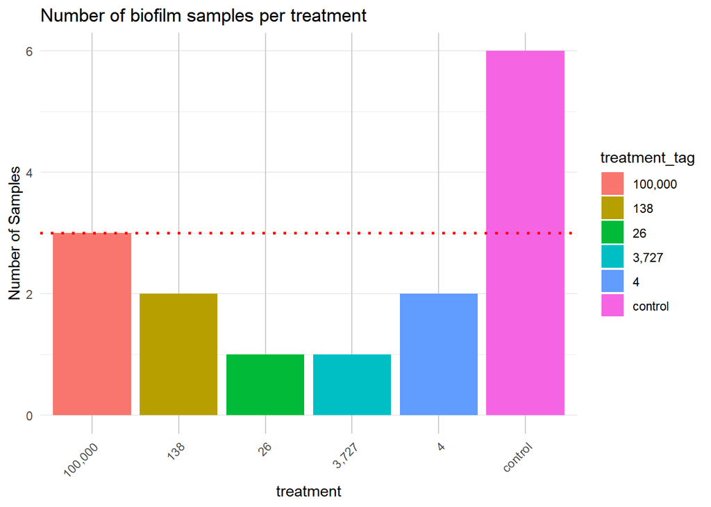

### 3.3.2 Proportion normalization

```
## OTU Table:          [5 taxa and 5 samples]
##                      taxa are rows
##                VenBB        VenDD         VenD VenF         VenG
## Zotu267 0.0000000000 0.0001811758 0.0000000000    0 0.0000000000
## Zotu325 0.0006423983 0.0014494066 0.0000000000    0 0.0003386673
## Zotu193 0.0012847966 0.0000000000 0.0020618557    0 0.0000000000
## Zotu226 0.0032119914 0.0010870550 0.0018744142    0 0.0000000000
## Zotu165 0.0014989293 0.0001811758 0.0005623243    0 0.0000000000
```

```
## VenBB VenDD  VenD  VenF  VenG  VenH
##     1     1     1     1     1     1
```

### 3.3.3 Cumulative Sum Scaling (CSS)

```
## OTU Table:          [5 taxa and 5 samples]
##                      taxa are columns
##        Zotu267   Zotu325   Zotu193  Zotu226  Zotu165
## VenBB  0.00000  25.21008  50.42017 126.0504 58.82353
## VenDD 21.97802 175.82418   0.00000 131.8681 21.97802
## VenD   0.00000   0.00000 239.13043 217.3913 65.21739
## VenF   0.00000   0.00000   0.00000   0.0000  0.00000
## VenG   0.00000  36.03604   0.00000   0.0000  0.00000
```

### 3.3.4 **Save phyloseq object for easy reloading**

**Saved phyloseq objects:**

- *ps_biofilm_final* (Unrarefied, filtered): `Venla_biofilm_phyloseq_filt_unnorm.RData`
- *ps_biofilm_rare* (Rarefied to even sequencing depth): `Venla_biofilm_phyloseq_filt_rar.RData`
- *ps_biofilm_prop* (Proportion-normalized to relative abundance): `Venla_biofilm_phyloseq_filt_propnorm.RData`
- *ps_biofilm_css* (CSS-normalized for compositionality and sequencing depth): `Venla_biofilm_phyloseq_filt_css.RData`